# Reproducible Research - Course Project 1

Daniel Wollmann

April 1, 2017

# Course Project 1 - Reproducible Research Week 2

## Initialization, Data Extract, Load and Transformation

This project uses libraries Lattice for plots and plyr for data operations for a few lines of code. During initialization, all data is loaded, data conversions are completed.

```r
library(lattice)
library(plyr)
dir <- "C:/Users/danielsw/OneDrive/Data Science Specialization/ReproducibleResearchWeek2/RepData_PeerAssessment1"
setwd(dir)
Data <- read.csv("activity.csv")
```

## What is the mean total number os steps taken per day?

```r
StepsPerDay <- aggregate(steps ~ date, Data, sum)
StepsMean <- mean(StepsPerDay$steps)
StepsMedian <- median(StepsPerDay$steps)
```

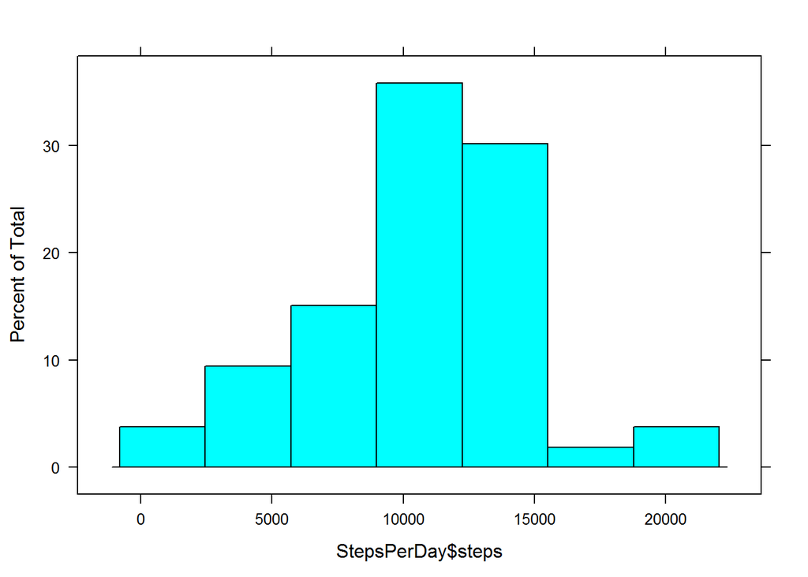

```r
histogram(StepsPerDay$steps)
```

## What is the average daily activity pattern?

Based on the time interval of the data sample, we can show the intervals with more or less activity. First step is to aggregate the mean of the steps per interval.

```r
StepsByIntervalMean <- aggregate(steps ~ interval, Data, mean)
```

Followed by plotting the distribution in a time series.

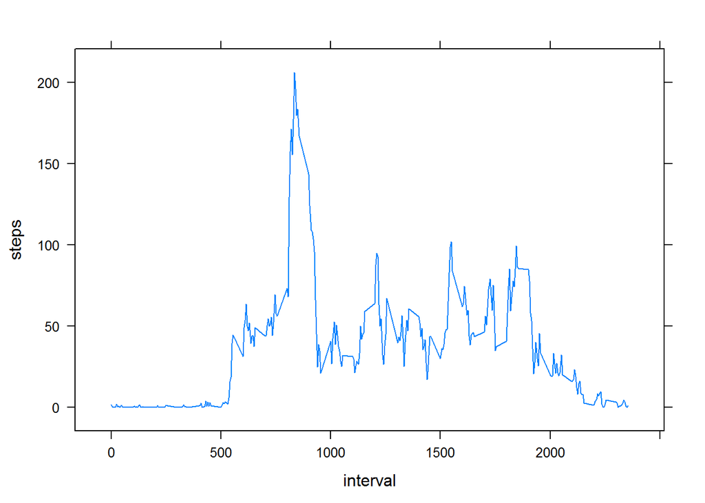

```r
xyplot(steps ~ interval, StepsByIntervalMean, type="l")
```

The maximum number of steps is 206.1698113.

## Inputting missing values

The data samples has multiple rows with missing steps data that can impact the analysis. Based on that we can normalize the data by replacing NA values with the mean of the values for the same interval. First step is to calculate the number of rows with missing data. In the dataset there are 2304 rows with missing steps data.

To replace the missing values we will copy the dataset and then via a loop indentify the rows with missing steps. Once a row is identified, we collect the interval number and calculate the mean of the steps from the same time interval. Finally, the values are replaced with the mean.

```r
CleanData <- Data
MaxRows <- nrow(Data)
index <- 1
while(index <= MaxRows){
    if(is.na(Data$steps[index])){
        CleanData$steps[index] <- StepsByIntervalMean$steps[which(StepsByIntervalMean$interval==Data$interval[index])]
    }
  index <- index + 1
}
StepsPerDay <- aggregate(steps ~ date,CleanData, sum, na.rm=TRUE)
```

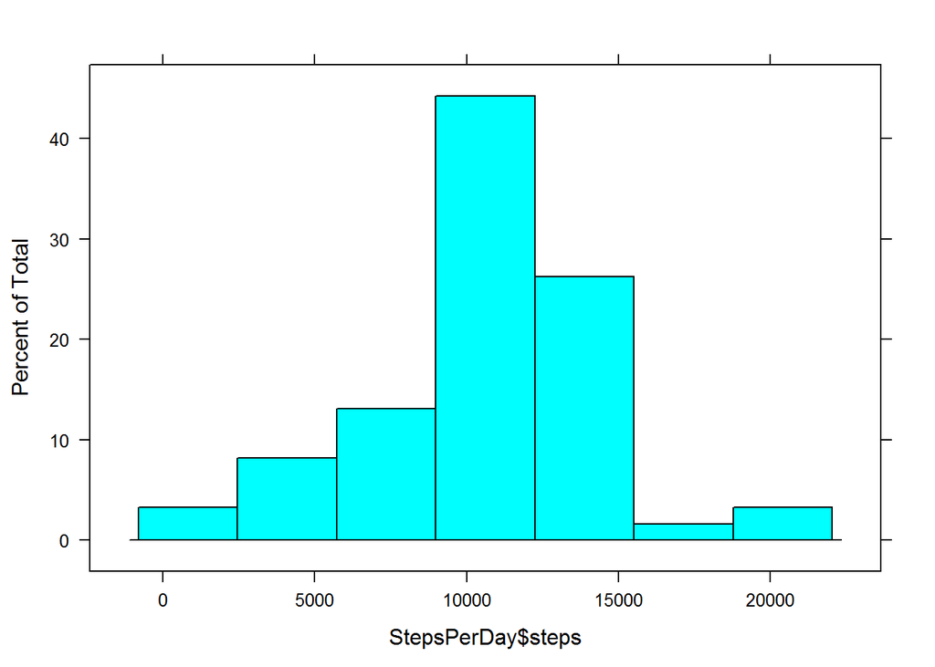

```r
histogram(StepsPerDay$steps)
```

## Are there any difference in the activity pattern between weekends and weekdays?

For this analysis we create a new column in the dataset to categorize if the activity falls in a weekday or weekend. To achieve that, I created a function ifelse to get the number of the weekday, and then using sapply we update the column with the type of day. Once that is completed, the data is aggregated in 3 columns, mean of steps by interval, interval number and type of day.

```r
CleanData$date <- as.Date.POSIXct(CleanData$date)

DayType <- function(v_date){
  d <- as.POSIXlt(as.Date(v_date))$wday
  return( ifelse(d==0||d==6,"Weekend","Weekday"))
}
CleanData$WeekTypeDay <- as.factor(sapply(Data$date, DayType))
StepsByIntervalWeekType <- aggregate(steps ~ interval + WeekTypeDay, CleanData, mean, na.rm=TRUE)
```

Now that we have the right aggregation, we can plot the data in a panel to compare activity levels between weekdays and weekends.

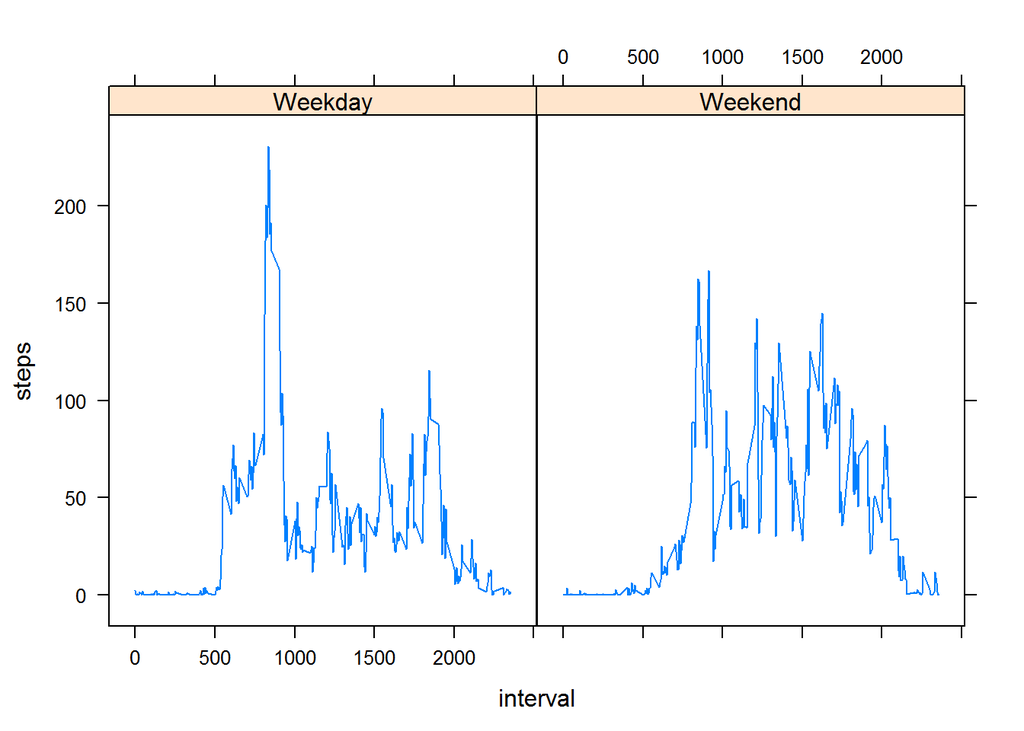

```r
xyplot(steps ~ interval | WeekTypeDay, data=StepsByIntervalWeekType, type="l")
```